# Sampler Documentation

Author

Jim Ianelli

[GitHub: afsc-assessments/sampler](https://github.com/afsc-assessments/sampler)

# 1 Overview

This repository contains two operational paths for generating sampler outputs:

1. ADMB executable workflow (legacy and still supported).
2. R refactor workflow (`R/sampler_refactor.R`) that preserves the same input file formats and writes tidy Parquet outputs.

Both paths use the same core input files:

- `sam*.dat` control files
- `age*.dat` age sample files
- `len*.dat` length sample files
- `bs_setup.dat` bootstrap settings

# 2 Repository Map

- `src/`: ADMB template (`sam.tpl`) and Makefile for compiling `sam`.
- `admb/`: alternate ADMB build area.
- `R/`: R scripts, including the refactor entry point.
- `example/`: small synthetic inputs for smoke testing.
- `cases/`: historical species/assessment-specific data and scripts.
- `index.qmd`: this documentation source.

# 3 Input File Formats

## 3.1 Control File (`sam*.dat`)

Token order expected by both ADMB (`src/sam.tpl`) and R (`R/sampler_refactor.R`):

| Position | Name | Description |
| --- | --- | --- |
| 1 | `year` | Model year label |
| 2 | `agefile` | Path to age file |
| 3 | `lenfile` | Path to length file |
| 4 | `na_rcrds` | Number of age records |
| 5 | `nl_rcrds` | Number of length records |
| 6 | `a1` | Min age |
| 7 | `a2` | Max age |
| 8 | `l1` | Min length bin |
| 9 | `l2` | Max length bin |
| 10 | `nstrata` | Number of strata |
| 11..(10+`nstrata`) | `strata_catch` | Catch by stratum |
| last | `outfile` | Main output file label |

Example (`example/sam2020.dat`):

```
2020 age2020.dat len2020.dat 6 6 2 5 30 38 1 100 results/Est_2020.dat
```

## 3.2 Age File (`age*.dat`)

Six columns:

```
strata haul sex age wt len
```

## 3.3 Length File (`len*.dat`)

Five columns:

```
strata haul sex len freq
```

## 3.4 Bootstrap Setup (`bs_setup.dat`)

Expected numeric values, one per line:

1. `nbs` (number of bootstrap iterations; `0`/`1` means no bootstrap expansion in many use cases)
2. `sam_level_age_tows`
3. `sam_level_ages`
4. `sam_level_lf_tows`
5. `sam_level_lfreqs`

Example (`example/bs_setup.dat`):

```
5
2
2
2
2
```

# 4 ADMB Workflow

## 4.1 Build

From repository root:

```bash
cd src
make clean
make
```

This compiles `sam` from `sam.tpl`.

## 4.2 Run

Run from a directory containing `sam*.dat`, `age*.dat`, `len*.dat`, and `bs_setup.dat` (for example `example/`):

```bash
cd example
../src/sam -ind sam2020.dat
```

## 4.3 ADMB Runtime Options

Options parsed in `sam.tpl`:

- `-io`: enable additional diagnostic printing.
- `-sim`: simulation mode flag.

Example:

```bash
../src/sam -nox -io -ind sam2020.dat
```

## 4.4 ADMB Outputs

ADMB writes multiple `.rep` files under `results/` (relative to the run directory), including:

- `sex_catage<year>.rep`
- `catage<year>.rep`
- `str_catage<year>.rep`
- `sex_wtage<year>.rep`
- `wtage<year>.rep`
- `str_wtage<year>.rep`
- `LF_<year>.rep`
- `alk_<year>.rep`
- `wl_<year>.rep`

# 5 R Refactor Workflow

Refactor entry point: `run_sampler_refactor()` in `R/sampler_refactor.R`.

## 5.1 Prerequisites

R packages:

- `data.table`
- `arrow`
- `ggplot2` (for plotting examples)

## 5.2 Recommended Run Commands

From repository root:

```bash
make example
```

Equivalent direct call:

```bash
cd example
R -q -e "source('../R/sampler_refactor.R'); run_sampler_refactor('sam2020.dat','bs_setup.dat','../results')"
```

### 5.2.1 Example: run and plot catch-at-age

This example runs the refactor and saves a quick diagnostic plot from the tidy Parquet output.

```bash
cd example
R -q <<'RS'
source('../R/sampler_refactor.R')
run_sampler_refactor('sam2020.dat', 'bs_setup.dat', '../results', 'sampler')

library(arrow)
library(data.table)
library(ggplot2)

dt <- as.data.table(read_parquet('../results/sampler_tidy.parquet'))
plot_dt <- dt[metric == 'catch_at_age' & !is.na(age),
              .(catch_at_age = sum(value, na.rm = TRUE)),
              by = .(year, age)][order(age)]

p <- ggplot(plot_dt, aes(x = age, y = catch_at_age)) +
  geom_line(linewidth = 0.8) +
  geom_point(size = 2) +
  scale_x_continuous(breaks = sort(unique(plot_dt$age))) +
  labs(
    title = sprintf('Sampler refactor catch-at-age (%s)', unique(plot_dt$year)),
    x = 'Age',
    y = 'Catch at age'
  ) +
  theme_minimal(base_size = 12)

ggsave('../results/sampler_catch_at_age.png', p, width = 7, height = 4, dpi = 150)
RS
```

## 5.3 Function Arguments

| Argument | Default | Description |
| --- | --- | --- |
| `control_file` | required | Path to `sam*.dat` |
| `bs_file` | `"bs_setup.dat"` | Path to bootstrap file |
| `out_dir` | `"results"` | Output directory |
| `out_prefix` | `"sampler"` | Output file prefix |

## 5.5 Notes on Paths

`sam*.dat` usually stores `agefile` and `lenfile` as relative names (for example `age2020.dat`). Use the same working directory as those files (for example `example/`) when running.

# 6 Core Equations

The model composes age and length information from fishery and survey samples with standard multinomial-style proportions and bootstrap summaries.

## 6.1 Length-frequency proportions

For year $y$, sex $s$, and length bin $l$:

$$p_{y,s,l} = \frac{n_{y,s,l}}{\sum_{l'} n_{y,s,l'}}$$

where $n_{y,s,l}$ is the sampled count at length.

## 6.2 Age-length key (ALK)

For age $a$ and length bin $l$:

$$P(a \mid l, y, s) = \frac{n_{y,s,a,l}}{\sum_{a'} n_{y,s,a',l}}$$

This maps observed length composition to age composition.

## 6.3 FTNIR-to-TMA age mapping (2024 onward)

Beginning in 2024, FTNIR ages are first mapped to traditional microscope ages (TMA) using an age-age key, analogous to an age-length key. In this step, FTNIR and TMA data are sex-aggregated.

For FTNIR age $a_F$ and TMA age $a_T$:

$$P(a_T \mid a_F, y) = \frac{n_{y,a_F,a_T}}{\sum_{a_T'} n_{y,a_F,a_T'}}$$

where $n_{y,a_F,a_T}$ are observed paired readings used to build the key.

In practice, this step converts FTNIR age compositions to TMA-equivalent age compositions first; then the standard sampler workflow proceeds (ALK application, catch-at-age, and roll-ups) using those mapped ages.

Updated 2024 bootstrap comparisons (FTNIR vs age-error adjusted) are shown below.

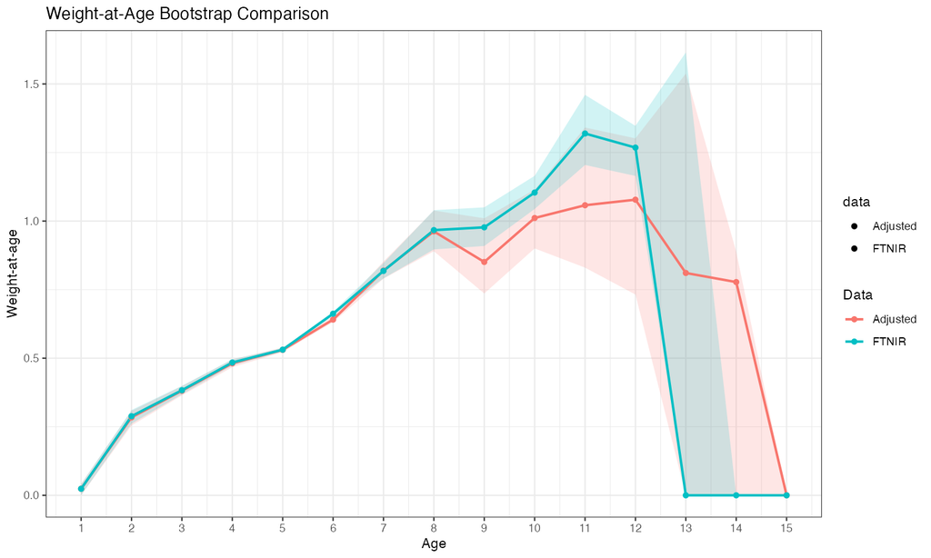

Weight-at-age bootstrap comparison by data source

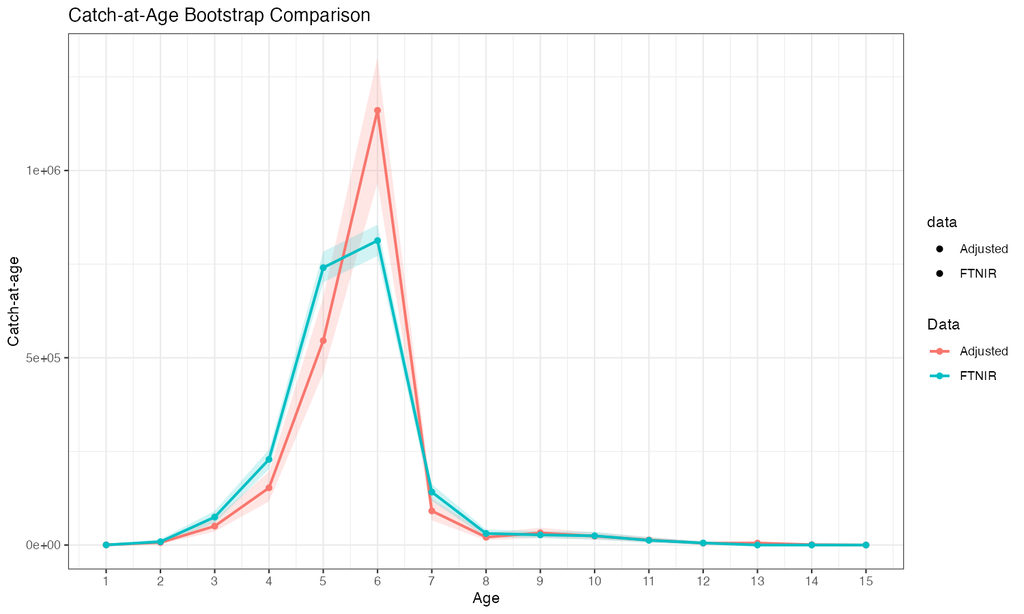

Catch-at-age bootstrap comparison by data source

## 6.4 Conditional ALK fallback for sparse cells

The ADMB implementation uses a fallback hierarchy when age data are missing within a given stratum/sex/length cell.

Let $n_{y,k,s,l,a}$ be age counts for year $y$, stratum $k$, sex $s$, length bin $l$, age $a$. Define three normalized ALKs at each length:

$$A^{(G)}_{y,l,a} =
\begin{cases}
\dfrac{n_{y,\cdot,\cdot,l,a}}{\sum_{a'} n_{y,\cdot,\cdot,l,a'}}, & \sum_{a'} n_{y,\cdot,\cdot,l,a'} > 0 \\
0, & \text{otherwise}
\end{cases}$$

$$A^{(S)}_{y,s,l,a} =
\begin{cases}
\dfrac{n_{y,\cdot,s,l,a}}{\sum_{a'} n_{y,\cdot,s,l,a'}}, & \sum_{a'} n_{y,\cdot,s,l,a'} > 0 \\
A^{(G)}_{y,l,a}, & \text{otherwise}
\end{cases}$$

$$A_{y,k,s,l,a} =
\begin{cases}
\dfrac{n_{y,k,s,l,a}}{\sum_{a'} n_{y,k,s,l,a'}}, & \sum_{a'} n_{y,k,s,l,a'} > 0 \\
A^{(S)}_{y,s,l,a}, & \text{otherwise}
\end{cases}$$

So missing cells are filled as: `stratum+sex+length` -> `sex+length` -> `global length`.

If a length bin has no age observations at any stratum or sex, then $A^{(G)}_{y,l,a}=0$ for all $a$, and downstream fallbacks remain zero at that length.

## 6.5 Catch-at-length and catch-at-age

Given total catch in numbers $C_{y,s}$:

$$C_{y,s,l} = C_{y,s} \cdot p_{y,s,l}$$

and catch-at-age is obtained by marginalizing over length:

$$C_{y,s,a} = \sum_l C_{y,s,l} \cdot P(a \mid l, y, s)$$

## 6.6 Mean weight-at-age and mean weight-at-length

For sampled weights $w_i$:

$$\bar{w}_{y,s,a} = \frac{1}{N_{y,s,a}} \sum_{i=1}^{N_{y,s,a}} w_i$$

$$\bar{w}_{y,s,l} = \frac{1}{N_{y,s,l}} \sum_{i=1}^{N_{y,s,l}} w_i$$

## 6.7 Strata roll-up in output files

In `results/Est_<year>.dat`, rows are stored as `year type stratum sex age value` with:

- `stratum = 1..H` for explicit strata,
- `stratum = 99` for all-strata aggregate,
- `sex = 99` for both-sex aggregate.

For stratum $k$, sex $s$, and age $a$, numbers-at-age are:

$$N_{y,k,s,a} = \sum_l \mathrm{LF}_{y,k,s,l}\, \mathrm{ALK}_{y,k,s,l,a}$$

where $\mathrm{LF}$ is the stratum-specific length frequency and $\mathrm{ALK}$ is the stratum-specific age-length key.

Define stratum-sex-age biomass-at-age as:

$$B_{y,k,s,a} = \sum_l \left(\mathrm{LF}_{y,k,s,l}\,\bar{w}_{y,k,s,l}\right)\, \mathrm{ALK}_{y,k,s,l,a}$$

and mean weight-at-age as:

$$\bar{w}_{y,k,s,a} = \frac{B_{y,k,s,a}}{N_{y,k,s,a}}$$

Roll-up equations used for `stratum=99` and/or `sex=99` are:

$$N_{y,k,99,a} = \sum_s N_{y,k,s,a}, \qquad
N_{y,99,s,a} = \sum_k N_{y,k,s,a}, \qquad
N_{y,99,99,a} = \sum_k \sum_s N_{y,k,s,a}$$

$$\bar{w}_{y,99,99,a} =
\frac{\sum_k \sum_s N_{y,k,s,a}\,\bar{w}_{y,k,s,a}}
{\sum_k \sum_s N_{y,k,s,a}}$$

So the annual/combined output is a stratum-weighted aggregation, not an unweighted average across strata.

## 6.8 Bootstrap summary statistics

From bootstrap replicates $\theta^{(b)}$, $b = 1,\dots,B$:

$$\hat{\mu}_\theta = \frac{1}{B} \sum_{b=1}^{B} \theta^{(b)}$$

$$\widehat{\mathrm{sd}}(\theta) = \sqrt{\frac{1}{B-1} \sum_{b=1}^{B} \left(\theta^{(b)} - \hat{\mu}_\theta\right)^2}$$

$$\mathrm{CV}(\theta) = \frac{\widehat{\mathrm{sd}}(\theta)}{\hat{\mu}_\theta}$$

# 7 `cases/ebswpSAM` Focus

This directory contains the Eastern Bering Sea walleye pollock workflow, with two practical data layouts:

## 7.1 Recommended: archived fishery run (`data/fishery`)

Run from the directory that contains the `samYYYY.dat` control files so relative `age/len` filenames resolve correctly.

### 7.1.1 ADMB run for one year

```bash
cd cases/ebswpSAM/data/fishery
cat > bs_setup.dat <<'TXT'
1
1
1
1
1
TXT
../../../../src/sam -ind sam2024.dat
```

### 7.1.2 R refactor run for one year

```bash
cd cases/ebswpSAM/data/fishery
cat > bs_setup.dat <<'TXT'
1000
2
2
2
2
TXT
R -q -e "source('../../../R/sampler_refactor.R'); run_sampler_refactor('sam2024.dat','bs_setup.dat','results','ebswp')"
```

## 7.2 Alternate: generated-data run (`cases/ebswpSAM/Makefile`)

`cases/ebswpSAM/Makefile` runs:

```bash
./sam -ind data/sam<year>.dat
```

Example:

```bash
cd cases/ebswpSAM
make yr=2024
```

Use this when `data/sam<year>.dat` exists (no underscore naming).

## 7.3 Consolidated driver (year ranges)

Use the single fishery driver to run ADMB over `data/samYYYY.dat` and write a rolled-up summary CSV:

```bash
cd cases/ebswpSAM
Rscript EBS_sampler_fishery.R start_year=1991 end_year=2024 nbs=1 levels=1,1,1,1
```

Common options:

- `start_year`, `end_year`: year range to run/read.
- `run_sampler=true|false`: run ADMB, or only summarize existing `results/Est_<year>.dat` files.
- `nbs`: first line for `bs_setup.dat` (for example `1` for point estimates, `1000` for bootstrap mode).
- `levels`: four comma-separated sampling controls for `bs_setup.dat` (for example `1,1,1,1`).
- `io=true|false`: pass `-nox -io` to `sam` when needed.

Summary-only example (no ADMB rerun):

```bash
cd cases/ebswpSAM
Rscript EBS_sampler_fishery.R start_year=1991 end_year=2024 run_sampler=false
```

## 7.4 Key ebswpSAM scripts

- `cases/ebswpSAM/EBS_sampler_fishery.R`: canonical fishery driver for year ranges in `data/fishery` (ADMB run + summary).
- `cases/ebswpSAM/EBS_sampler.R`: compatibility wrapper to run the consolidated driver with default full range.
- `cases/ebswpSAM/EBS_sampler2021.R`, `cases/ebswpSAM/EBS_sampler2022.R`, `cases/ebswpSAM/EBS_sampler2023.R`: compatibility wrappers pinned to historical end years.
- `cases/ebswpSAM/sampler.R`: legacy helper definitions (`Sampler()`, `SetBS()`) used by earlier workflows.
- `cases/ebswpSAM/ebs_survey.R`: survey-oriented conversion and sampler runs.
- `cases/ebswpSAM/imported/poll_age.sql` and `cases/ebswpSAM/imported/poll_len.sql`: source SQL templates.

## 7.5 Known path caveats

- Several legacy scripts in this case directory contain machine-specific `setwd()`/`source()` paths and may need local edits before execution.
- Some scripts reference `sampleR/R/sampler_EBSwp.R`; verify that file exists in your local clone or update the `source()` target to the intended sampler helper.

# 8 Query-Based Data Preparation

These query scripts live in `R/`:

- `R/CallQueriesForSamplerData.R`
- `R/QueryAgesForSampler.R`
- `R/QueryLengthsForSampler.R`
- `R/QueryCatchByStrata.R`

These use AFSC/AKFIN ODBC connections and keyring credentials to generate `age*.dat`, `len*.dat`, and `sam*.dat` files.

# 9 Appendix: (Roxygen)

Source: `cases/ebswpSAM/EBS_sampler_fishery.R`

The table below is a concise rendering of the roxygen function documentation in the consolidated driver.

| Function | Purpose | Key Parameters | Return |
| --- | --- | --- | --- |
| `get_script_dir()` | Resolve script directory for CLI or sourced execution. | none | Absolute directory path (`character`). |
| `as_bool(x, default = FALSE)` | Parse truthy/falsey CLI text to logical. | `x`, `default` | Logical scalar. |
| `parse_cli_args(args)` | Parse `key=value` CLI tokens into a named list. | `args` | Named list of string values. |
| `discover_control_years(fishery_dir)` | Detect available years from `samYYYY.dat` controls. | `fishery_dir` | Sorted integer year vector. |
| `write_bs_setup(fishery_dir, nbs, levels)` | Write `bs_setup.dat` controls for ADMB. | `fishery_dir`, `nbs`, `levels` (length 4) | Path to written file. |
| `run_sampler_year(year, fishery_dir, sam_bin, io = FALSE, verbose = TRUE)` | Run ADMB `sam` for one control year. | `year`, `fishery_dir`, `sam_bin`, `io`, `verbose` | Invisibly `TRUE` on success. |
| `read_estimates(year, fishery_dir)` | Read one `results/Est_<year>.dat` file. | `year`, `fishery_dir` | `data.table` or `NULL` if missing. |
| `summarize_estimates(est_dt)` | Roll up combined (`stratum=99`) annual numbers and mean age. | `est_dt` | Yearly summary `data.table`. |
| `run_ebswp_fishery(...)` | Main consolidated workflow for year-range run + summary. | `start_year`, `end_year`, `run_sampler`, `nbs`, `levels`, `io`, `fishery_dir`, `sam_bin`, `summary_csv`, `verbose` | Invisible list: `years`, `summary_csv`, `n_rows`. |

# 10 Render This Documentation

From repository root:

```bash
quarto render index.qmd
```

This produces `index.html` in the repository root.

# 11 Push to GitHub

Typical update sequence:

```bash
git add index.qmd index.html
git commit -m "Update sampler documentation"
git push origin <branch>
```

If your repository uses GitHub Pages from root or `gh-pages`, commit `index.html` accordingly.

# 12 Troubleshooting

- `Package 'arrow' is required for Parquet output.`
  - Install `arrow` in your R library before running the refactor.
- `quarto: command not found`
  - Install Quarto and ensure it is on your PATH.
- ADMB binary not found
  - Ensure `admb` and/or compiled `sam` exists and is executable.